# R Notebook

# Lab Week

## Summary Statistics

### Wine dataset

Import and parse the wine dataset from the UCI machine learning repository into R. You can browse the contents of the dataset at https://archive.ics.uci.edu/static/public/109/wine.zip. Make sure you add column names and the correct column type for each column.

1. Calculate the mean value for Alcohol.

```r
# Download the wine.zip file from UCI
url <- 'https://archive.ics.uci.edu/static/public/109/wine.zip' # define the url
download.file(url, destfile = 'wine.zip') # downlaods the zip
unzip('wine.zip', list = T) # just has a look at whats inside it
```

| Name | Length | Date |
| --- | --- | --- |
| Index | 105 | 2023-05-22 22:22:00 |
| wine.data | 10782 | 2023-05-22 22:22:00 |
| wine.names | 3036 | 2023-05-22 22:22:00 |

```r
unzip('wine.zip', exdir = './wine') # extracts to folder /wine directory
list.files('./wine') # lissts whats been extracted an dint he new folder
```

```
[1] "Index"      "wine.data"  "wine.names"
```

```r
# import the data intoa  dataframe or tibble
# When you use functions like read_csv() or read_delim(), the col_names argument tells R whether the first row of your data file contains column headers (names) or actual data.
# if you use col_names = TRUE , R assumes the first row of your file contains column names, not data
library(readr)
wine_tbl <- read_delim('./wine/wine.data', delim=',', col_names = FALSE)
spec(wine_tbl)
class(wine_tbl)
```

```
[1] "spec_tbl_df" "tbl_df"      "tbl"         "data.frame"
```

```r
is_tibble(wine_tbl)
```

```
Error in is_tibble(wine_tbl) : could not find function "is_tibble"
```

1s. check dataset type tibble or dataframe

```r
class(wine_tbl)
```

[output not shown]

```r
library(tibble)
is_tibble(wine_tbl)
```

[output not shown]

```r
# tibble  >>> into >>? dataframe
wine_tbl <- as.data.frame(wine_tbl)
class(wine_tbl)
```

```
[1] "data.frame"
```

```r
is_tibble(wine_tbl)
```

```
[1] FALSE
```

```r
# dataframe >>> into a >>>> tibble
wine_tbl <- as_tibble(wine_df)
class(wine_tbl)
```

[output not shown]

```r
is_tibble(wine_tbl)
```

```
[1] TRUE
```

2. Calculate the median value for Malic Acid

```r
# When you use functions like read_csv() or read_delim(), the col_names argument tells R whether the first row of your data file contains column headers (names) or actual data.
# if you use col_names = TRUE , R assumes the first row of your file contains column names, not data
library(readr)
wine_tbl <- read_delim('./wine/wine.data', delim=',', col_names = FALSE)
spec(wine_tbl)
# assign proper column names from the wine.names file for the columns
colnames(wine_tbl) <- c(
  "Class",
  "Alcohol",
  "Malic_Acid",
  "Ash",
  "Alcalinity_of_Ash",
  "Magnesium",
  "Total_Phenols",
  "Flavanoids",
  "Nonflavanoid_Phenols",
  "Proanthocyanins",
  "Color_Intensity",
  "Hue",
  "OD280_OD315",
  "Proline"
)

median_malic <- median(wine_tbl$Malic_Acid)
paste (" The median valeu for mailc acid is ", median_malic)
```

```
[1] " The median valeu for mailc acid is  1.865"
```

```r
summary(wine_tbl)
```

```
     Class          Alcohol        Malic_Acid         Ash        Alcalinity_of_Ash   Magnesium
 Min.   :1.000   Min.   :11.03   Min.   :0.740   Min.   :1.360   Min.   :10.60     Min.   : 70.00
 1st Qu.:1.000   1st Qu.:12.36   1st Qu.:1.603   1st Qu.:2.210   1st Qu.:17.20     1st Qu.: 88.00
 Median :2.000   Median :13.05   Median :1.865   Median :2.360   Median :19.50     Median : 98.00
 Mean   :1.938   Mean   :13.00   Mean   :2.336   Mean   :2.367   Mean   :19.49     Mean   : 99.74
 3rd Qu.:3.000   3rd Qu.:13.68   3rd Qu.:3.083   3rd Qu.:2.558   3rd Qu.:21.50     3rd Qu.:107.00
 Max.   :3.000   Max.   :14.83   Max.   :5.800   Max.   :3.230   Max.   :30.00     Max.   :162.00
 Total_Phenols     Flavanoids    Nonflavanoid_Phenols Proanthocyanins Color_Intensity
 Min.   :0.980   Min.   :0.340   Min.   :0.1300       Min.   :0.410   Min.   : 1.280
 1st Qu.:1.742   1st Qu.:1.205   1st Qu.:0.2700       1st Qu.:1.250   1st Qu.: 3.220
 Median :2.355   Median :2.135   Median :0.3400       Median :1.555   Median : 4.690
 Mean   :2.295   Mean   :2.029   Mean   :0.3619       Mean   :1.591   Mean   : 5.058
 3rd Qu.:2.800   3rd Qu.:2.875   3rd Qu.:0.4375       3rd Qu.:1.950   3rd Qu.: 6.200
 Max.   :3.880   Max.   :5.080   Max.   :0.6600       Max.   :3.580   Max.   :13.000
      Hue          OD280_OD315       Proline
 Min.   :0.4800   Min.   :1.270   Min.   : 278.0
 1st Qu.:0.7825   1st Qu.:1.938   1st Qu.: 500.5
 Median :0.9650   Median :2.780   Median : 673.5
 Mean   :0.9574   Mean   :2.612   Mean   : 746.9
 3rd Qu.:1.1200   3rd Qu.:3.170   3rd Qu.: 985.0
 Max.   :1.7100   Max.   :4.000   Max.   :1680.0
```

3. Calculate the five major percentile values for Flavanoids

```r
# only workls on single numeric column
# fivenum(wine_tbl)

# to ONLY APLY IT TO COLI,NS THATARE NUMERIC
sapply(wine_tbl[, sapply(wine_tbl, is.numeric)], fivenum)
```

[output not shown]

4. Calculate the 23rd Percentile for Proanthocyanins

```r
names(wine_tbl)
```

```
 [1] "Class"                "Alcohol"              "Malic_Acid"           "Ash"
 [5] "Alcalinity_of_Ash"    "Magnesium"            "Total_Phenols"        "Flavanoids"
 [9] "Nonflavanoid_Phenols" "Proanthocyanins"      "Color_Intensity"      "Hue"
[13] "OD280_OD315"          "Proline"
```

```r
percntl_23 <- quantile(wine_tbl$Proanthocyanins, .23)

print(paste0("The 23rd percentile of Proanthocyanins is ", percntl_23))
```

```
[1] "The 23rd percentile of Proanthocyanins is 1.15"
```

5. Calculate the mean value for all columns (this can be done as one liner)

```r
# lapply() is an R function that applies a function to each element of a list (or vector) and returns a list. Think of it as a “loop in one line.”
# sapply() is very similar to lapply() but with a key difference: it tries to simplify the result.

sapply(wine_tbl, function(x) mean(x, na.rm = TRUE))
```

```
               Class              Alcohol           Malic_Acid                  Ash
           1.9382022           13.0006180            2.3363483            2.3665169
   Alcalinity_of_Ash            Magnesium        Total_Phenols           Flavanoids
          19.4949438           99.7415730            2.2951124            2.0292697
Nonflavanoid_Phenols      Proanthocyanins      Color_Intensity                  Hue
           0.3618539            1.5908989            5.0580899            0.9574494
         OD280_OD315              Proline
           2.6116854          746.8932584
```

```r
# 🔍 Explanation:
#  - sapply() applies a function to each column of a data frame or tibble.
#  - mean(x, na.rm = TRUE) computes the mean for each column while ignoring NA values.
#  - It will return a named numeric vector showing the mean for each column.
# -  function(x) ? is a function without a name — defined on the fly and used inside another function (like sapply()). “For each element (here, each column) in wine_tbl, call it x, and then do something with it. ie.. get the mean .. 3 parameters in the brackets”
# function(x) defines an inline (anonymous) function.
# x represents one element from the data (in this case, each column).
# It’s commonly used in apply, lapply, sapply, map, and tidyverse functions.


# restrict it to numeric colmns only - "is.mnumeric"
# sapply automaticalyl returns a vector instead of a list so mean_list is a vector...
mean_list <- sapply(wine_tbl[sapply(wine_tbl, is.numeric)], mean, na.rm = TRUE)
print(mean_list \n)
```

```
Error: unexpected '\\' in "print(mean_list \"
```

For the questions below, you might want to use a for loop to work through each column. You can print the results to the console.

6. Calculate which column displays the greatest and least standard deviation

```r
# sapply(wine_tbl, function(x) sd(x, na.rm = TRUE))

sd_list <-sapply(wine_tbl[sapply(wine_tbl, is.numeric)], sd, na.rm = TRUE)



sd_list <- round(sort(sd_list), 3)
print(sd_list)
```

```
Nonflavanoid_Phenols                  Hue                  Ash      Proanthocyanins
               0.124                0.229                0.274                0.572
       Total_Phenols          OD280_OD315                Class              Alcohol
               0.626                0.710                0.775                0.812
          Flavanoids           Malic_Acid      Color_Intensity    Alcalinity_of_Ash
               0.999                1.117                2.318                3.340
           Magnesium              Proline
              14.282              314.907
```

```r
print(paste(" the min stanard deviatin avlue is : ", sd_list[1]))
```

```
[1] " the min stanard deviatin avlue is :  0.124"
```

```r
print(paste(" the max stanard deviatin avlue is : ", tail(sd_list, 1)))
```

```
[1] " the max stanard deviatin avlue is :  314.907"
```

```r
print(paste(" different  =  is : ", tail(sd_list, 1) - sd_list[1]))
```

```
[1] " different  =  is :  314.783"
```

7. Using the standard deviation calculation, work out each column’s variance (do not use the built-in R function)

```r
var_list <- sd_list^2
print(var_list)
```

```
Nonflavanoid_Phenols                  Hue                  Ash      Proanthocyanins
            0.015376             0.052441             0.075076             0.327184
       Total_Phenols          OD280_OD315                Class              Alcohol
            0.391876             0.504100             0.600625             0.659344
          Flavanoids           Malic_Acid      Color_Intensity    Alcalinity_of_Ash
            0.998001             1.247689             5.373124            11.155600
           Magnesium              Proline
          203.975524         99166.418649
```

```r
for (i in var_list) {
  print(paste("variance is ", i))
}
```

```
[1] "variance is  0.015376"
[1] "variance is  0.052441"
[1] "variance is  0.075076"
[1] "variance is  0.327184"
[1] "variance is  0.391876"
[1] "variance is  0.5041"
[1] "variance is  0.600625"
[1] "variance is  0.659344"
[1] "variance is  0.998001"
[1] "variance is  1.247689"
[1] "variance is  5.373124"
[1] "variance is  11.1556"
[1] "variance is  203.975524"
[1] "variance is  99166.418649"
```

8. For each column, calculate the interquartile range

```r
iqr_list <-sapply(wine_tbl[sapply(wine_tbl, is.numeric)], IQR, na.rm = TRUE)

# sort in ascending order
iqr_list <- sort(iqr_list)

# pritn out column names also, unline earlier for loops which just took values..
for (name in names(iqr_list)) {
  print(paste(name, "IQR value is  :", iqr_list[name], "\n"))
}
```

```
[1] "Nonflavanoid_Phenols IQR value is  : 0.1675 \n"
[1] "Hue IQR value is  : 0.3375 \n"
[1] "Ash IQR value is  : 0.3475 \n"
[1] "Proanthocyanins IQR value is  : 0.7 \n"
[1] "Total_Phenols IQR value is  : 1.0575 \n"
[1] "OD280_OD315 IQR value is  : 1.2325 \n"
[1] "Alcohol IQR value is  : 1.315 \n"
[1] "Malic_Acid IQR value is  : 1.48 \n"
[1] "Flavanoids IQR value is  : 1.67 \n"
[1] "Class IQR value is  : 2 \n"
[1] "Color_Intensity IQR value is  : 2.98 \n"
[1] "Alcalinity_of_Ash IQR value is  : 4.3 \n"
[1] "Magnesium IQR value is  : 19 \n"
[1] "Proline IQR value is  : 484.5 \n"
```

9. For each column, calculate whether the distribution is left or right skewed

```r
# ifelse(condition, value_if_true, value_if_false)
# is a vectorized if statement in R.
# It checks a condition for each element of a vector.
# Returns one of two values depending on whether that condition is TRUE or FALSE.

skew_direction <- ifelse(mean_list > median_list, "Right-skewed",
                    ifelse(mean_list < median_list, "Left-skewed",
                           "Approximately symmetric"))

# Creates a data frame — basically a table — combining several vectors that are the same length.
# So you’re building a summary table that has:
# Variable names,
# Their mean,
# Their median,
# Their skew direction (left/right/symmetric).


skew_summary <- data.frame(
  Variable = names(mean_list),
  Mean = round(mean_list, 3),
  Median = round(median_list, 3),
  Direction = skew_direction,
  row.names = NULL
)

# or create a tibble instead of dataframe above (nicer visualisatuin apprarently)
library(tibble)
skew_summary <- tibble(
  Variable = names(mean_list),
  Mean = round(mean_list, 3),
  Median = round(median_list, 3),
  Direction = skew_direction
)


print(skew_summary)
```

| Variable | Mean | Median | Direction |
| --- | --- | --- | --- |
| Class | 1.938 | 2.000 | Left-skewed |
| Alcohol | 13.001 | 13.050 | Left-skewed |
| Malic_Acid | 2.336 | 1.865 | Right-skewed |
| Ash | 2.367 | 2.360 | Right-skewed |
| Alcalinity_of_Ash | 19.495 | 19.500 | Left-skewed |
| Magnesium | 99.742 | 98.000 | Right-skewed |
| Total_Phenols | 2.295 | 2.355 | Left-skewed |
| Flavanoids | 2.029 | 2.135 | Left-skewed |
| Nonflavanoid_Phenols | 0.362 | 0.340 | Right-skewed |
| Proanthocyanins | 1.591 | 1.555 | Right-skewed |

[output cut: 4 more lines]

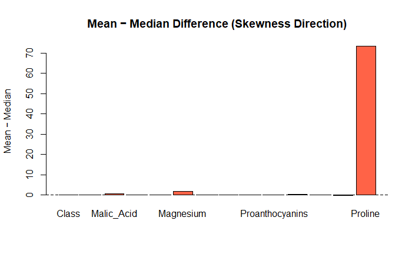

```r
#optional visualisation
barplot(mean_list - median_list,
        main = "Mean − Median Difference (Skewness Direction)",
        ylab = "Mean − Median",
        col = ifelse(mean_list > median_list, "tomato", "steelblue"))
abline(h = 0, lty = 2)
```

```r
NA
NA
NA
```

### Airquality dataset

Load the airquality dataset which is available with the baseR package. (You can use the R data function to load built-in datasets).

```r
data <- airquality
str(data)
```

```
'data.frame':   153 obs. of  6 variables:
 $ Ozone  : int  41 36 12 18 NA 28 23 19 8 NA ...
 $ Solar.R: int  190 118 149 313 NA NA 299 99 19 194 ...
 $ Wind   : num  7.4 8 12.6 11.5 14.3 14.9 8.6 13.8 20.1 8.6 ...
 $ Temp   : int  67 72 74 62 56 66 65 59 61 69 ...
 $ Month  : int  5 5 5 5 5 5 5 5 5 5 ...
 $ Day    : int  1 2 3 4 5 6 7 8 9 10 ...
```

```r
str(data)
```

```
'data.frame':   153 obs. of  6 variables:
 $ Ozone  : int  41 36 12 18 NA 28 23 19 8 NA ...
 $ Solar.R: int  190 118 149 313 NA NA 299 99 19 194 ...
 $ Wind   : num  7.4 8 12.6 11.5 14.3 14.9 8.6 13.8 20.1 8.6 ...
 $ Temp   : int  67 72 74 62 56 66 65 59 61 69 ...
 $ Month  : int  5 5 5 5 5 5 5 5 5 5 ...
 $ Day    : int  1 2 3 4 5 6 7 8 9 10 ...
```

1. Calculate the total number of NAs in the Solar.R column.

```r
# number of missing from solar column
sum(is.na(airquality$Solar.R))
```

```
[1] 7
```

```r
# ask R
# allmissing <- is.na(data)
# print(allmissing)
#
# # # get a count for eacjh column
# counts <- colSums(allMissing)
# print(counts)
# # only the columnsthat have missing NAs
# print(paste(" percentage NAs is ", (round(counts/nrow(data)*100, 2))))


# # check for missing values
# allMissing <- is.na(data)
#
# # count NAs per column
# counts <- colSums(allMissing)
#
# # calculate percentage of missing values per column
# percent_NA <- round(counts / nrow(data) * 100, 2)
#
# # print results
# print(paste("Percentage of NAs is:", percent_NA))
```

2. Calculate the total number of NAs in row 5

```r
sum(is.na(airquality[5, ]))
```

```
[1] 2
```

3. Calculate the mean of the Ozone column (the answer is not NA!).

```r
mean_list <- sapply(data[sapply(data, is.numeric)], mean, na.rm = TRUE)
print(mean_list['Ozone'])
```

```
   Ozone
42.12931
```

```r
print(mean_list[1])
```

```
   Ozone
42.12931
```

4. Calculate the percentage of rows which contain at least 1 NA

```r
# check which rows have any NA
rows_with_NA <- rowSums(is.na(airquality)) > 0

# count how many rows have at least one NA
num_rows_with_NA <- sum(rows_with_NA)

# calculate percentage
percent_rows_with_NA <- (num_rows_with_NA / nrow(airquality)) * 100

# print results
cat("Number of rows with at least one NA:", num_rows_with_NA, "\n")
```

```
Number of rows with at least one NA: 42
```

```r
cat("Percentage of rows with at least one NA:", round(percent_rows_with_NA, 2), "%\n")
```

```
Percentage of rows with at least one NA: 27.45 %
```

5. Calculate the total number of NAs for each column

```r
# check which rows have any NA
cols_with_NA <- colSums(is.na(airquality))

print(cols_with_NA)
```

```
  Ozone Solar.R    Wind    Temp   Month     Day
     37       7       0       0       0       0
```